# Nur ein wenig lineare Regression

Norman Markgraf

2018-01-08

Der *tipping* Datensatz wird oft analysiert. Das Verhältnis von Trinkgeld (*tip*) und Rechnungsbetrag (*total_bill*) steht dabei im Vordergrund einer lineare Regressionsanalyse. So auch hier. Wir wollen die einzelnen Angaben von **R** dabei in den Fokus rücken und einmal Hinterfragen, was wir bei der Ausgabe von **R** eigentlich genau sehen, woher es kommt und wie man es interprätieren kann.

Eine lineares Modell wird schnell mit

```r
linMod <- lm(tip ~ total_bill, data = tips)
```

erstellt. Betrachten wir nun die Zusammenfassung:

```r
summary(linMod)
```

```
##
## Call:
## lm(formula = tip ~ total_bill, data = tips)
##
## Residuals:
##     Min      1Q  Median      3Q     Max
## -3.1982 -0.5652 -0.0974  0.4863  3.7434
##
## Coefficients:
##             Estimate Std. Error t value Pr(>|t|)
## (Intercept) 0.920270   0.159735   5.761 2.53e-08 ***
## total_bill  0.105025   0.007365  14.260  < 2e-16 ***
## ---
## Signif. codes:  0 '***' 0.001 '**' 0.01 '*' 0.05 '.' 0.1 ' ' 1
##
## Residual standard error: 1.022 on 242 degrees of freedom
## Multiple R-squared:  0.4566, Adjusted R-squared:  0.4544
## F-statistic: 203.4 on 1 and 242 DF,  p-value: < 2.2e-16
```

Die zentrale Frage bei einer linearen Regression ist, finden wir einen linearen Zusammenhang in unserer Stichprobe, den wir auf die Population (als die Grundgesamtheit) übertragen können.

Die Spalte **Estimate** im Abschnitt **Coefficients** liefert uns in unser Stichprobe einen möglichen linearen Zusammenhang gemäß

$$\hat{y}_{\text{tip}} = \hat{\beta}_{\text{0}} + \hat{\beta}_{\text{total_bill}} \cdot x_{\text{total_bill}},$$

mit den *Regressionskoeffizienten* $\hat{\beta}_0=0.9202696$ und $\hat{\beta}_{\text{total_bill}}=0.1050245$.

Graphisch ergibt sich damit das Modell wie folgt:

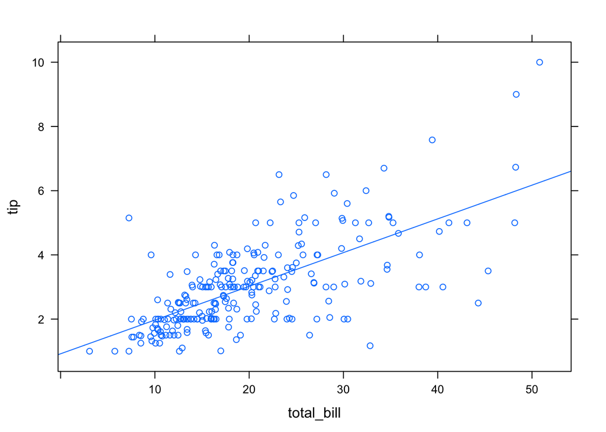

```r
plotModel(linMod)
```

Was hat es nun mit dem y-Achenabschnitt $\hat{\beta}_0$ aufsich?

Ist es etwa eine Art *Grundtrinkgeld*, mit dem der Kellern rechnen kann, auch wenn der Kunde gar nichts bestellt?

Nun ja, es so etwas in der Art, aber eben ein rein fiktiver Wert, der durch die Konstruktion der Parameter entsteht. Eine (affin-)lineare Gerade geht nun einmal irgendwann durch die y-Achse (wenn sie nicht parallel dazu ist) und es kann passieren, dass eine sinnvolle Interpretation nicht so ohne weiteres möglich ist.

Wir können aber dieses *Grundtrinkgeld* herraus nehmen und den y-Achenabschnitt auf Null setzen. Dazu ziehen wir $\hat{\beta}_0$ einfach von alle Trinkgeldern ab. Wir erhalten quasi nur noch den *Trinkgeldzuwach*.

```r
beta_0 <- coef(linMod)["(Intercept)"]  # Grundtrinkgeld
tips$delta_tip <- tips$tip - beta_0    # wird abgezogen
```

Vergleichen wir das alte lineare Modell mit dem neuen Modell (*linModDelta*):

```r
linModDelta <- lm(delta_tip ~ total_bill, data = tips)
summary(linModDelta)
```

```
##
## Call:
## lm(formula = delta_tip ~ total_bill, data = tips)
##
## Residuals:
##     Min      1Q  Median      3Q     Max
## -3.1982 -0.5652 -0.0974  0.4863  3.7434
##
## Coefficients:
##               Estimate Std. Error t value Pr(>|t|)
## (Intercept) -4.549e-15  1.597e-01    0.00        1
## total_bill   1.050e-01  7.365e-03   14.26   <2e-16 ***
## ---
## Signif. codes:  0 '***' 0.001 '**' 0.01 '*' 0.05 '.' 0.1 ' ' 1
##
## Residual standard error: 1.022 on 242 degrees of freedom
## Multiple R-squared:  0.4566, Adjusted R-squared:  0.4544
## F-statistic: 203.4 on 1 and 242 DF,  p-value: < 2.2e-16
```

In diesem Modell ist der Wert für den y-Achenabschnitt numerisch gleich 0. – Ja, da mag zwar $-4.5487837\times 10^{-15}$ stehen, jedoch sind so kleine Werte der jedem Rechner inne wohnenden Ungenauigkeit in der Gleitkomma-Arithmetik geschuldet und wind faktisch gleich 0.

Der Wert für die Steigung lautet weiterhin $0.1050245$. Das war auch zu erwarten, denn wir haben unsere Regressionsgerade eigentlich nur um $\hat{\beta}_0$ nach unten verschoben. (Der Fachmann spricht von einer Translation (Parallelverschiebung)[^1] um $-\hat{\beta}_0$.

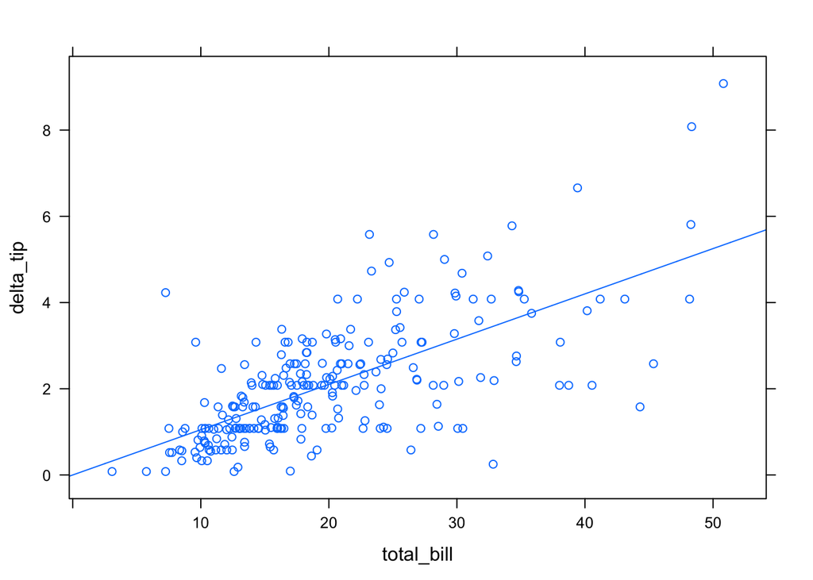

```r
plotModel(linModDelta)
```

Vergleichen wir die beiden Zusammenfassungen, so stellen wir fest das sich mit Aussnahme der *[Intercept]* Zeile parktisch nichts geändert hat. Das ist kein Wunder, sondern Absicht!

Die Regressionsgerade stellt für unsere Stichprobe die Gerade mit dem geringsten Fehler an den Datenpunkten dar. Mathematisch heißt das folgendes:

An den $n=244$ Datenpunkten unserer Stichprobe $(x_i, y_i)=(tips\$total\_bill[i], tips\$tip[i])$ [für (i=1,,n)$] sind die *Residuen*, also die *Fehlerterme*,
$$\hat{e}_i =\hat{y}_i - y_i = \left[\hat{\beta}_{\text{0}} + \hat{\beta}_{\text{total_bill}} \cdot x_i\right] - y_i$$

durch die verwendete *Methode der kleinsten Quadrate*[^2] *quadratisch minimal*. Kurz:

$$\sum_{i=1}^n (\hat{e}_i)^2 \text{ ist minimal!}$$

Wir können uns nun diese Fehlerterme auch graphisch Ansehen um die Varianz der Residuen zu sehen. Dazu siehen wir von allen Datenpunkt $y_i$ den geschätzen Wert $\hat{y}_i$ ab und erstellen ein neues lineares Modell

```r
beta_total_bill <- coef(linModDelta)["total_bill"]
tips$error_tip <- (tips$tip - beta_0 - beta_total_bill * tips$total_bill)
linModError <- lm(error_tip ~ total_bill, data = tips)
summary(linModError)
```

```
##
## Call:
## lm(formula = error_tip ~ total_bill, data = tips)
##
## Residuals:
##     Min      1Q  Median      3Q     Max
## -3.1982 -0.5652 -0.0974  0.4863  3.7434
##
## Coefficients:
##               Estimate Std. Error t value Pr(>|t|)
## (Intercept)  1.900e-15  1.597e-01       0        1
## total_bill  -8.740e-17  7.365e-03       0        1
##
## Residual standard error: 1.022 on 242 degrees of freedom
## Multiple R-squared:  6.665e-31,  Adjusted R-squared:  -0.004132
## F-statistic: 1.613e-28 on 1 and 242 DF,  p-value: 1
```

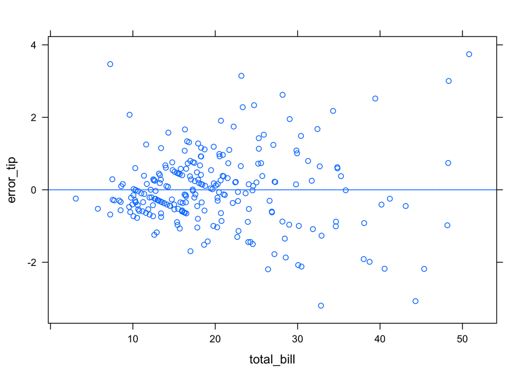

```r
plotModel(linModError)
```

Wir können die Graphik im wesendlichen auch einfacher über den Befehl

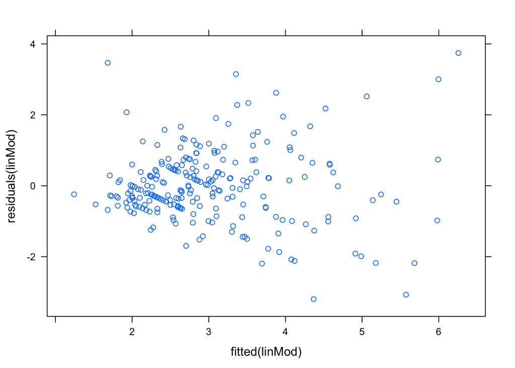

```r
xyplot(residuals(linMod) ~ fitted(linMod))
```

erhalten.

Betrachten wir kurz nur die Rediduen:

```r
favstats(~residuals(linMod))
```

```
##        min         Q1      median        Q3      max          mean
##  -3.198225 -0.5651615 -0.09744499 0.4863111 3.743435 -2.022281e-17
##        sd   n missing
##  1.019943 244       0
```

Wir sehe, dass wir in der Zusammenfassung immer genau diese Werte unter dem Abschnitt *Residuals* gefunden haben. Minimum, das 1. Quantil, der Median, das 3. Quantil und das Maximum stimmen überein.

Der erwartungstreue und unverzerrte Schätzer für den Standardfehler der Residuen, lautet

$$\begin{align*}
SE_{\text{Residuen}} &= \sqrt{\frac{1}{n-2} \cdot \sum_{i=1}^n (\hat{e_i})^2} = \sqrt{\frac{n-1}{n-2} \cdot \frac{1}{n-1} \cdot \sum_{i=1}^n (\hat{e_i})^2} \\
&= \sqrt{\frac{n-1}{n-2}} \cdot \sqrt{\frac{1}{n-1} \cdot \sum_{i=1}^n (\hat{e_i})^2} \\
&= \sqrt{\frac{n-1}{n-2}} \cdot s_{\text{Residuen}}
\end{align*}$$

Also finden wir den Wert *Residual standard error* aus der Zeile

```
Residual standard error: 1.022 on 242 degrees of freedom
```

in dem wir den in den *favstats* gefundenen Wert für die Standardabweichung entsprechen korrigieren:

$$SE_{\text{Residuen}} = \sqrt{\frac{n-1}{n-2}} \cdot s_{\text{Residuen}} = \sqrt{\frac{243}{242}} \cdot 1.0199426 = 1.0220477$$

Der Median der Residuen ist nicht gleich Null, wie der Mittelwert. (Welcher auch hier als numerisch Null interpretiert werden muss!) Es könnte also eine linkssteile, rechtsschiefe Verteilung der Resiuden vorliegen. Betrachten wir dazu das Histogramm:

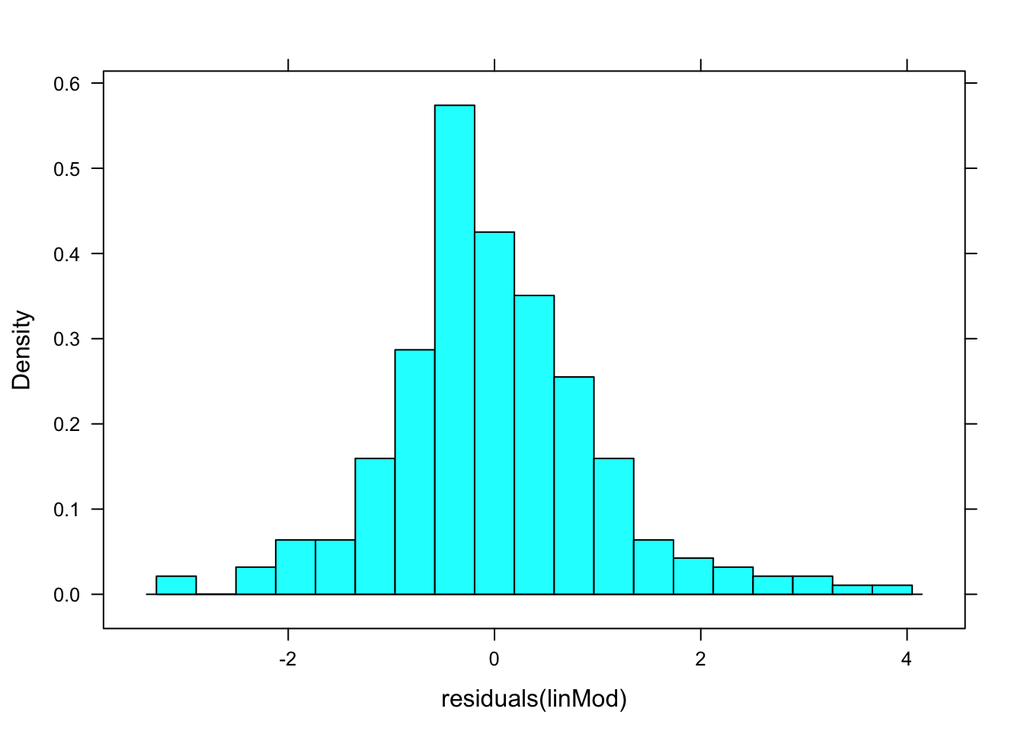

```r
histogram( ~residuals(linMod), nint=19)
```

Schon beim ersten Blick auf das Histogramm kann an eine Normalverteilung der Residuen nicht mehr so ganz geglaubt werden.

Ein Shapiro-Wilk-Test[^3] hat als Nullhypothese $H_0$ die Annahme, dass die Daten normalverteilt sind!

```r
shapiro.test( residuals(linMod) )
```

```
##
##  Shapiro-Wilk normality test
##
## data:  residuals(linMod)
## W = 0.96728, p-value = 2.171e-05
```

Davon ist nach dem Ergebnis eben sowenig auszugehen, wie nach einem Blick auf das QQ-Normal-Diagram:

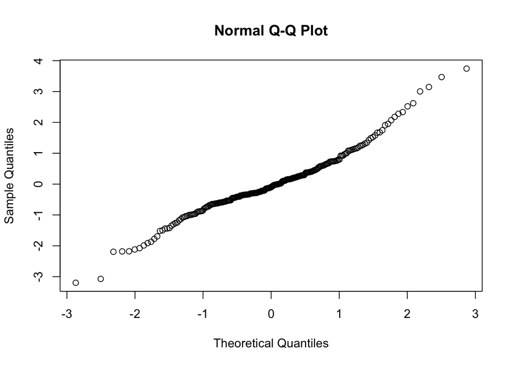

```r
qqnorm( residuals(linMod) )
```

[^1]: vgl: https://de.wikipedia.org/wiki/Parallelverschiebung
[^2]: vgl: https://de.wikipedia.org/wiki/Methode_der_kleinsten_Quadrate
[^3]: vgl: https://de.wikipedia.org/wiki/Shapiro-Wilk-Test